# Stem Cell Biomarker Expression

Erin Chille

Last updated: 2020/11/09

## Set up workspace

Remove prior objects and load necessary tools

```r
rm(list=ls()) # removes all prior objects

library("RColorBrewer")
library("ggplot2")
library("tidyverse")
library("ggpubr")
library("DESeq2")
library("genefilter")
```

Load sample Information

```r
sample.info <- read.csv(file="Sample_Info/RNAseq_data.csv", header=T, sep=",") #load sample info
```

Load gene count Information

```r
counts <- as.data.frame(read.csv("1-QC-Align-Assemble/Output/gene_count_matrix.csv", row.names="gene_id"), colClasses = double) #Load normalized expression matrix from stringtie
```

#### Quality-filter gene counts

Pre-filtering our dataset to reduce the memory size dataframe, increase the speed of the transformation and testing functions, and improve quality of statistical analysis by removing low-coverage counts. Removed counts could represent outliers in the data and removing these improves sensitivity of statistical tests. Here we will filter out the genes that are only present in fewer than two of the 24 ambient samples.

```r
#keep only ambient treatmentinfo and count data
dev <- c("AMB")
treatmentinfo_dev <- filter(sample.info, treatment %in% dev)
dim(treatmentinfo_dev) #rows should be 24
```

```
## [1] 24  4
```

```r
# delete sample columns corresponding to low and extreme low samples by mapping Null value to them
gcount_dev <- counts[treatmentinfo_dev$sample_id]
dim(gcount_dev) #columns should be 24
```

```
## [1] 63227    24
```

```r
#create filter for the counts data
#gfiltdev <- rowSums(count(gcount_dev)) > 0
#set filter values for PoverA, P=100% percent of the samples have counts over A=10. This means that only 2 out of 24 (0.083) samples need to have counts over 10. Our smallest sample size for our life stages is two (fertilized egg, mid-gastrula, early-gastrula). By setting 2/24 as the P, this means if a particular gene is expressed only in 1 of these smallest life stages, it will be included in the analysis.
filt <- filterfun(pOverA(0.083,10))

#create filter for the counts data
gfiltdev <- genefilter(gcount_dev, filt)

#identify genes to keep by count filter
gkeepdev <- gcount_dev[gfiltdev,]


#identify genes to keep by count filter
gkeepdev <- gcount_dev[gfiltdev,]

#identify gene lists
gn.keepdev <- rownames(gkeepdev)

#gene count data filtered in PoverA, P percent of the samples have counts over A
gcount_filt_dev <- as.data.frame(gcount_dev[which(rownames(gcount_dev) %in% gn.keepdev),])

#How many rows do we have before and after filtering?
nrow(gcount_dev) #Before
```

```
## [1] 63227
```

```r
nrow(gcount_filt_dev) #After
```

```
## [1] 32772
```

In order for the DESeq2 algorithms to work, the SampleIDs on the treatmentinfo file and count matrices have to match exactly and in the same order. The following R clump will check to make sure that these match.

```r
#Checking that all row and column names match. Should return "TRUE"
all(treatmentinfo_dev$sample_id %in% colnames(gcount_filt_dev))
```

```
## [1] TRUE
```

```r
all(treatmentinfo_dev$sample_id == colnames(gcount_filt_dev))
```

```
## [1] TRUE
```

### Read normalization

We are now going normalize our read counts using VST-normalization in DESeq2

#### Construct the DESeq2 dataset

```r
treatmentinfo_dev$time_point <- factor(treatmentinfo_dev$time_point, levels = c("Unfertilized_egg", "Fertilized_egg", "Cleavage", "Prawn_chip", "Early_gastrula", "Mid_gastrula", "Late_gastrula", "Planula", "Adult"))
```

Create a DESeqDataSet design from gene count matrix and labels. Here we set the design to look at time_point to test for any differences in gene expression across timepoints.

```r
#Set DESeq2 design
gdds_dev <- DESeqDataSetFromMatrix(countData = gcount_filt_dev,
                              colData = treatmentinfo_dev,
                              design = ~time_point)
```

#### Log-transform the count data

First we are going to log-transform the data using a variance stabilizing transforamtion (VST). This is only for visualization purposes. Essentially, this is roughly similar to putting the data on the log2 scale. It will deal with the sampling variability of low counts by calculating within-group variability (if blind=FALSE). Importantly, it does not use the design to remove variation in the data, and so can be used to examine if there may be any variability do to technical factors such as extraction batch effects.

To do this we first need to calculate the size factors of our samples. This is a rough estimate of how many reads each sample contains compared to the others. In order to use VST (the faster log2 transforming process) to log-transform our data, the size factors need to be less than 4. Otherwise, there could be artefacts in our results.

```r
SF.gdds_dev <- estimateSizeFactors(gdds_dev) #estimate size factors to determine if we can use vst  to transform our data. Size factors should be less than for to use vst
print(sizeFactors(SF.gdds_dev)) #View size factors
```

```
##      X119      X120      X121      X127      X132      X153      X154      X159
## 1.0519967 0.5686680 0.7558557 0.5351080 0.5251546 1.0029584 1.8794576 0.7811492
##      X162      X163      X167      X179      X180      X184      X212      X215
## 1.5226504 1.7499897 1.7848493 1.0151292 0.8308898 0.9339607 1.1350398 0.8053938
##      X218      X221      X359      X361      X375     X1101     X1548     X1628
## 1.6504284 1.1560682 1.4281348 1.3679823 1.0904351 1.2882416 0.8315212 0.9180700
```

Our size factors are all less than 4, so we can use VST!

```r
gvst_dev <- vst(gdds_dev, blind=FALSE) #apply a variance stabilizing transforamtion to minimize effects of small counts and normalize wrt library size
head(assay(gvst_dev), 3) #view transformed gene count data
```

```
##            X119     X120     X121     X127     X132     X153     X154     X159
## g16981 8.873991 8.873991 9.127751 8.873991 8.873991 8.873991 8.873991 9.403881
## g16985 8.873991 8.873991 8.873991 8.873991 8.873991 8.873991 8.873991 8.873991
## g16984 8.873991 8.873991 8.873991 8.873991 8.873991 8.873991 8.873991 8.873991
##            X162     X163     X167     X179     X180     X184     X212     X215
## g16981 9.173980 9.125417 8.873991 9.129687 9.116050 9.224550 8.873991 8.873991
## g16985 8.873991 8.873991 8.873991 8.873991 8.873991 8.873991 8.873991 9.022359
## g16984 8.873991 8.873991 8.873991 8.873991 8.873991 8.873991 8.936504 8.873991
##            X218     X221     X359     X361     X375    X1101    X1548    X1628
## g16981 9.184462 9.079270 9.168398 9.174778 9.717659 9.521989 9.372258 9.796006
## g16985 8.873991 8.873991 9.096707 8.954515 9.075528 9.085384 8.947025 9.124311
## g16984 8.977659 8.981261 8.985432 9.086872 9.120722 9.303627 8.873991 8.873991
```

Find mean, median, mode of expression

```r
#Make a list of observations
exp_df <- as.data.frame(assay(gvst_dev))
exp_list <- c(exp_df$X119, exp_df$X120, exp_df$X121, exp_df$X127, exp_df$X132, exp_df$X153, exp_df$X154, exp_df$X159, exp_df$X162, exp_df$X163, exp_df$X167, exp_df$X179, exp_df$X180, exp_df$X184, exp_df$X212, exp_df$X215, exp_df$X218, exp_df$X221, exp_df$X359, exp_df$X361, exp_df$X375, exp_df$X1101, exp_df$X1548, exp_df$X1628)
sanity.check <- nrow(exp_df)*ncol(exp_df) #make sure num observations match
length(exp_list) == sanity.check #make sure num observations match. Should be true.
```

```
## [1] TRUE
```

```r
#Get stats and view distribution as a histogram
max(exp_list)
```

```
## [1] 19.30772
```

```r
mean(exp_list)
```

```
## [1] 9.58362
```

```r
median(exp_list)
```

```
## [1] 9.223431
```

```r
min(exp_list)
```

```
## [1] 8.873991
```

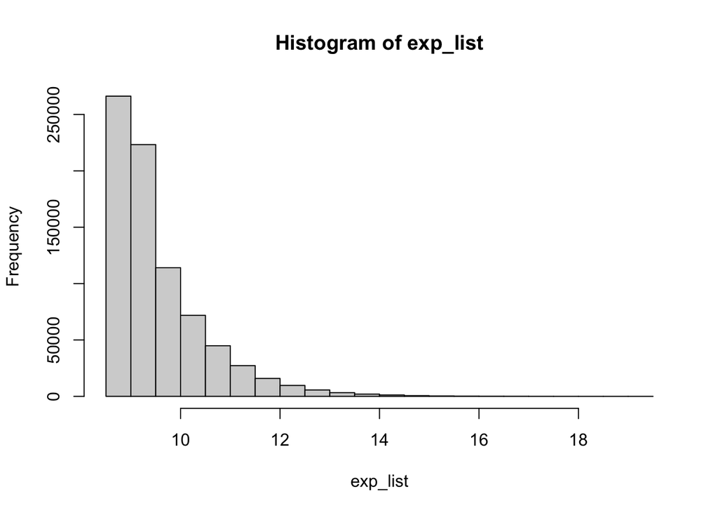

```r
hist(exp_list)
```

## Run BLAST search of biomarkers against Mcap protein fasta

Find orthologues of biomarkers within Mcap genome

```bash
#Make blast database from Mcap predicted protein fasta file
#/usr/local/ncbi/blast/bin/makeblastdb -in {path2ref}/Mcap.protein.fa -input_type fasta -dbtype prot -parse_seqids -out 2b-Epi-MZT-Enzyme-Expression/Input/Mcap.protein.blast.db

#Blast fasta file containing sequences of selected biomarkers against our sequences
#/usr/local/ncbi/blast/bin/blastp -query 2b-Epi-MZT-Enzyme-Expression/Input/stem_query.fasta -db 2b-Epi-MZT-Enzyme-Expression/Input/Mcap.protein.blast.db -outfmt 6 -max_target_seqs 100 -evalue 1e-05 -out 2b-Epi-MZT-Enzyme-Expression/Output/Mcap_stem_biomarker_hits.csv

#Manually in text editor: (1.) Add column names: "queryprot", "gene_id", "pident", "length", "mismatch", "gapopen", "qstart", "qend", "sstart", "send", "evalue", "bitscore", and (2.) Remove ("augustus." and ".t1") from gene_ids using "command F" replace
#Manually in Excel: Add a column called Enzyme_Name that lists the alias for each of your target of enzymes. Check the annotation to see if there is any overlap in genes
```

Subset results for genes of interest

```r
hits <- read.table(file="2b-Epi-MZT-Enzyme-Expression/Output/Mcap_stem_biomarker_hits.csv", col.names=c("Enzyme_Name","gene_id","pident", "length", "mismatch", "gapopen", "qstart", "qend", "sstart", "ssend", "evalue", "bitscore"))
hits <- hits %>% distinct(Enzyme_Name, gene_id, .keep_all = TRUE)
hits <- hits %>% group_by(Enzyme_Name) %>% distinct(sstart, ssend, .keep_all = TRUE)
hits$gene_id <- gsub("augustus.", "", hits$gene_id)
hits$gene_id <- gsub(".t1", "", hits$gene_id)
levels(as.factor(hits$Enzyme_Name))
```

```
## [1] "HSFP5" "MYBL1" "NANOS" "PIWI"  "RFX3"  "SOLH2" "VASA"
```

```r
countsx <- as.data.frame(assay(gvst_dev))
gene.counts <- countsx[(row.names(countsx) %in% hits$gene_id), ]
#str(gene.counts)
gene.counts$gene_id <- row.names(gene.counts)
gene.counts <- merge(gene.counts, hits[,c(1,2)], by="gene_id")

gene.counts.long <- pivot_longer(gene.counts, 2:25, values_to = "exp")
  #gather(gene.counts, group, exp, X1101:X375, factor_key=TRUE)
colnames(gene.counts.long)[3] <- "sample_id"
gene.counts.long <- merge(gene.counts.long, sample.info[,c(1:2)], by="sample_id")
#str(gene.counts.long)

mean.counts <- gene.counts.long %>%
  group_by(gene_id, Enzyme_Name, time_point) %>%
  summarise(mean = mean(exp),
            sd=sd(exp))
mean.counts$time_point <- factor(mean.counts$time_point,
                                 levels = c("Unfertilized_egg","Fertilized_egg","Cleavage",
                                  "Prawn_chip","Early_gastrula","Mid_gastrula", "Late_gastrula",
                                  "Planula", "Adult"))
levels(as.factor(mean.counts$Enzyme_Name))
```

```
## [1] "HSFP5" "MYBL1" "NANOS" "PIWI"  "RFX3"  "SOLH2" "VASA"
```

```r
HSFP5.counts <- subset(mean.counts, Enzyme_Name =="HSFP5")
nHSFP5 <- length(levels(as.factor(HSFP5.counts$gene_id)))
MYBL1.counts <- subset(mean.counts, Enzyme_Name =="MYBL1")
nMYBL1 <- length(levels(as.factor(MYBL1.counts$gene_id)))
NANOS.counts <- subset(mean.counts, Enzyme_Name =="NANOS")
nNANOS <- length(levels(as.factor(NANOS.counts$gene_id)))
RFX3.counts <- subset(mean.counts, Enzyme_Name =="RFX3")
nRFX3 <- length(levels(as.factor(RFX3.counts$gene_id)))
SOLH2.counts <- subset(mean.counts, Enzyme_Name =="SOLH2")
nSOLH2 <- length(levels(as.factor(SOLH2.counts$gene_id)))
VASA.counts <- subset(mean.counts, Enzyme_Name =="VASA")
nVASA <- length(levels(as.factor(VASA.counts$gene_id)))
PIWI.counts <- subset(mean.counts, Enzyme_Name =="PIWI")
nPIWI <- length(levels(as.factor(PIWI.counts$gene_id)))

nhomologues <- as.data.frame(cbind(HSFP5=nHSFP5, MYBL1=nMYBL1, NANOS=nNANOS, RFX3=nRFX3, SOLH2=nSOLH2, VASA=nVASA, PIWI=nPIWI))
print(nhomologues)
```

```
##   HSFP5 MYBL1 NANOS RFX3 SOLH2 VASA PIWI
## 1     2     3     2    5     1   47    8
```

Select only the top hit for each enzyme for plotting.

```r
top_HSFP5=c("g61783")
top_MYBL1=c("g47070")
top_NANOS=c("g56764")
top_RFX3=c("g45492")
top_SOLH2=c("g41670")
top_VASA=c("adi2mcaRNA36621_R2")
top_PIWI=c("g67777")
```

## Plot methylation-related genes

Plot MYBL1a expression as a function of time and treatment

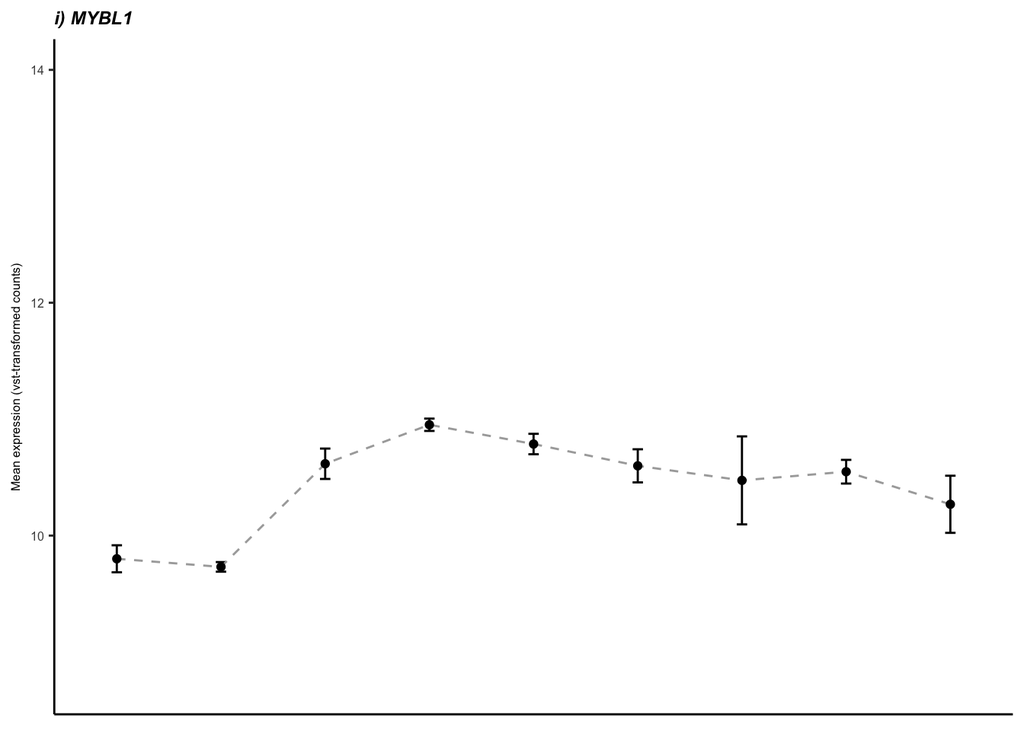

```r
Mcap.MYBL1 <- MYBL1.counts %>% subset(gene_id%in%top_MYBL1) %>%
  ggplot(aes(x=time_point, y=mean, group=gene_id)) +
  geom_errorbar(aes(ymin=mean-sd, ymax=mean+sd), width=.1) +
  geom_line(aes(), lty="dashed", color = "darkgrey") +
  geom_point(aes(), size = 1.5) +
  xlab("Timepoint") +
  ylab(expression(paste("Mean expression (vst-transformed counts)"))) +
  theme_bw() + #Set the background color
  ylim(8.728599, 14) +
  theme(axis.line = element_line(color = 'black'), #Set the axes color
        panel.border = element_blank(), #Set the border
        panel.grid.major = element_blank(), #Set the major gridlines
        panel.grid.minor = element_blank(), #Set the minor gridlines
        plot.background=element_blank(),  #Set the plot background
        axis.title.x=element_blank(), #set x-axis title size
        axis.text.x=element_blank(), #set x-axis label size
        axis.text.y=element_text(size = 6), #set x-axis label size
        axis.title.y=element_text(size = 6), #set x-axis label size
        axis.ticks.x=element_blank(), #No x-label ticks
        legend.text=element_text(size = 6), #Legend text size
        legend.title=element_text(size = 6), #Legend title size
        legend.position=c(0.75, 0.9)) +
  ggtitle("i) MYBL1") +
  #facet_grid(rows=vars(gene_id), scales="free_y") +
  theme(strip.text.y = element_text(size = 5)) +
  theme(plot.title = element_text(face = 'bold.italic',
                                  size = 9,
                                  hjust = 0)) #+
  #annotate("text", x = 3, y = 14, label = "de novo methylation", size = 2.5)
Mcap.MYBL1
```

Plot PIWI expression as a function of time and treatment

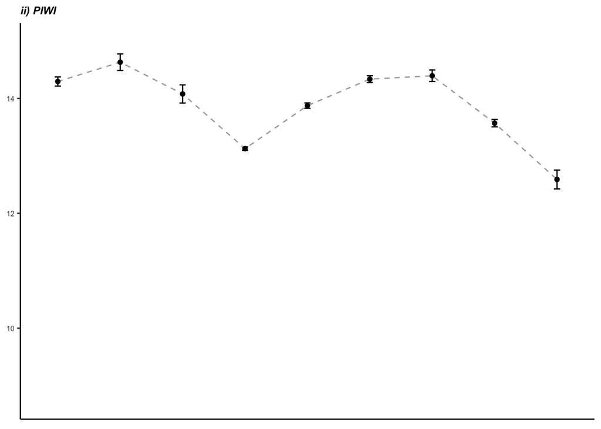

```r
Mcap.PIWI <- PIWI.counts %>% subset(gene_id%in%top_PIWI) %>%
  ggplot(aes(x=time_point, y=mean, group=gene_id)) +
  geom_errorbar(aes(ymin=mean-sd, ymax=mean+sd), width=.1) +
  geom_line(aes(), lty="dashed", color = "darkgrey") +
  geom_point(aes(), size = 1.5) +
  xlab("Timepoint") +
  ylab(expression(paste("Mean normalized expression"))) +
  theme_bw() + #Set the background color
  ylim(8.728599, 15) +
  theme(axis.line = element_line(color = 'black'), #Set the axes color
        panel.border = element_blank(), #Set the border
        panel.grid.major = element_blank(), #Set the major gridlines
        panel.grid.minor = element_blank(), #Set the minor gridlines
        plot.background=element_blank(),  #Set the plot background
        axis.title.x=element_blank(), #set x-axis title size
        axis.text.x=element_blank(), #set x-axis label size
        axis.text.y=element_text(size = 6), #set x-axis label size
        axis.title.y=element_blank(), #set x-axis label size
        axis.ticks.x=element_blank(), #No x-label ticks
        legend.text=element_text(size = 6), #Legend text size
        legend.title=element_text(size = 6), #Legend title size
        legend.position=c(0.75, 0.9)) +
  ggtitle("ii) PIWI") +
  #facet_grid(rows=vars(gene_id), scales="free_y") +
  theme(strip.text.y = element_text(size = 5)) +
  theme(plot.title = element_text(face = 'bold.italic',
                                  size = 9,
                                  hjust = 0)) #+
  #annotate("text", x = 3.5, y = 14, label = "methylation maintenance", size = 2.5)
Mcap.PIWI
```

Plot NANOS expression as a function of time and treatment

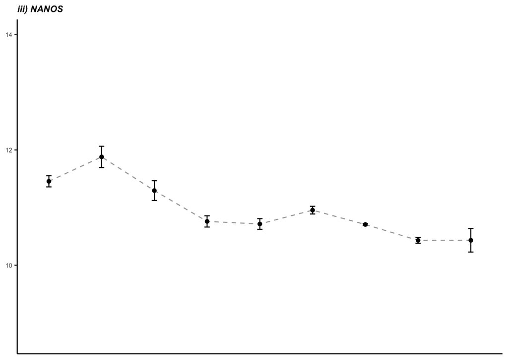

```r
Mcap.NANOS <- NANOS.counts %>% subset(gene_id%in%top_NANOS) %>%
  ggplot(aes(x=time_point, y=mean, group=gene_id)) +
  geom_errorbar(aes(ymin=mean-sd, ymax=mean+sd), width=.1) +
  geom_line(aes(), lty="dashed", color = "darkgrey") +
  geom_point(aes(), size = 1.5) +
  xlab("Timepoint") +
  ylab(expression(paste("Mean expression (vst-transformed counts)"))) +
  theme_bw() + #Set the background color
  ylim(8.728599, 14) +
  theme(axis.line = element_line(color = 'black'), #Set the axes color
        panel.border = element_blank(), #Set the border
        panel.grid.major = element_blank(), #Set the major gridlines
        panel.grid.minor = element_blank(), #Set the minor gridlines
        plot.background=element_blank(),  #Set the plot background
        axis.title.x=element_blank(), #set x-axis title size
        axis.text.x=element_blank(), #set x-axis label size
        axis.text.y=element_text(size = 6), #set x-axis label size
        axis.title.y=element_blank(), #set x-axis label size
        axis.ticks.x=element_blank(), #No x-label ticks
        legend.text=element_text(size = 6), #Legend text size
        legend.title=element_text(size = 6), #Legend title size
        legend.position=c(0.75, 0.9)) +
  ggtitle("iii) NANOS") +
  #facet_grid(rows=vars(gene_id), scales="free_y") +
  theme(strip.text.y = element_text(size = 5)) +
  theme(plot.title = element_text(face = 'bold.italic',
                                  size = 9,
                                  hjust = 0)) #+
  #annotate("text", x = 3, y = 14, label = "methylation removal", size = 2.5)
Mcap.NANOS
```

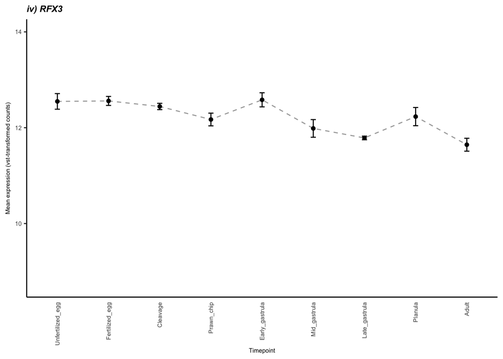

```r
Mcap.RFX3 <- RFX3.counts %>% subset(gene_id%in%top_RFX3) %>%
  ggplot(aes(x=time_point, y=mean, group=gene_id)) +
  geom_errorbar(aes(ymin=mean-sd, ymax=mean+sd), width=.1) +
  geom_line(lty="dashed", color = "darkgrey") +
  geom_point(aes(), size = 1.5) +
  xlab("Timepoint") +
  ylab(expression(paste("Mean expression (vst-transformed counts)"))) +
  theme_bw() + #Set the background color
  ylim(8.728599, 14) +
  theme(axis.line = element_line(color = 'black'), #Set the axes color
        panel.border = element_blank(), #Set the border
        panel.grid.major = element_blank(), #Set the major gridlines
        panel.grid.minor = element_blank(), #Set the minor gridlines
        plot.background=element_blank(),  #Set the plot background
        axis.title.x=element_text(size = 6), #set x-axis title size
        axis.text.x=element_text(angle = 90, vjust = 0.5, hjust=1, size = 6), #set x-axis label size
        axis.text.y=element_text(size = 6), #set x-axis label size
        axis.title.y=element_text(size = 6), #set x-axis label size
        axis.ticks.x=element_blank(), #No x-label ticks
        legend.text=element_text(size = 6), #Legend text size
        legend.title=element_text(size = 6), #Legend title size
        legend.position=c(0.75, 0.9)) +
  ggtitle("iv) RFX3") +
  #facet_grid(rows=vars(gene_id), scales="free_y") +
  theme(strip.text.y = element_text(size = 5)) +
  theme(plot.title = element_text(face = 'bold.italic',
                                  size = 9,
                                  hjust = 0)) #+
  #annotate("text", x = 3.5, y = 14, label = "transcriptional repression", size = 2.5)
Mcap.RFX3
```

Plot SOLH2 expression as a function of time and treatment

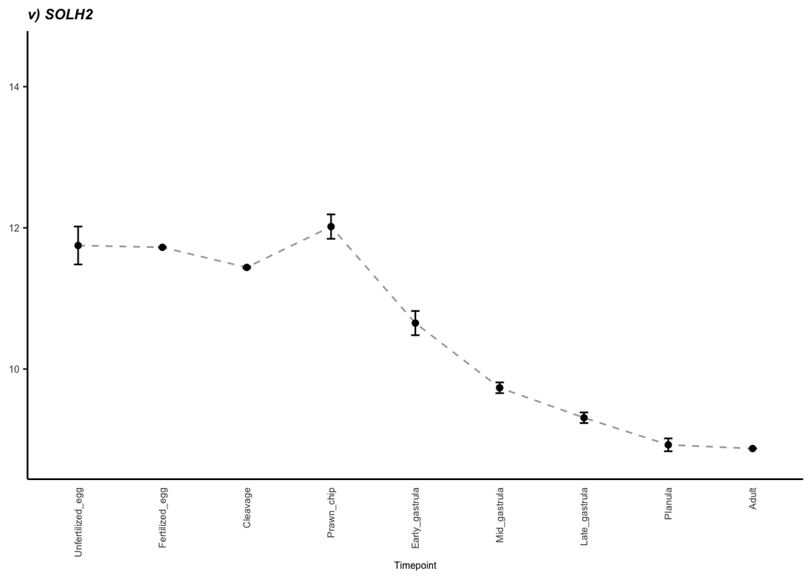

```r
Mcap.SOLH2 <- SOLH2.counts %>% subset(gene_id%in%top_SOLH2) %>%
  ggplot(aes(x=time_point, y=mean, group=gene_id)) +
  geom_errorbar(aes(ymin=mean-sd, ymax=mean+sd), width=.1) +
  geom_line(lty="dashed", color = "darkgrey") +
  geom_point(aes(), size = 1.5) +
  xlab("Timepoint") +
  ylab(expression(paste("Mean expression (vst-transformed counts)"))) +
  theme_bw() + #Set the background color
  ylim(8.728599, 14.5) +
  theme(axis.line = element_line(color = 'black'), #Set the axes color
        panel.border = element_blank(), #Set the border
        panel.grid.major = element_blank(), #Set the major gridlines
        panel.grid.minor = element_blank(), #Set the minor gridlines
        plot.background=element_blank(),  #Set the plot background
        axis.title.x=element_text(size = 6), #set x-axis title size
        axis.text.x=element_text(angle = 90, vjust = 0.5, hjust=1, size = 6), #set x-axis label size
        axis.text.y=element_text(size = 6), #set x-axis label size
        axis.title.y=element_blank(), #set x-axis label size
        axis.ticks.x=element_blank(), #No x-label ticks
        legend.text=element_text(size = 6), #Legend text size
        legend.title=element_text(size = 6), #Legend title size
        legend.position=c(0.75, 0.85)) +
  ggtitle("v) SOLH2") +
  #facet_grid(rows=vars(gene_id), scales="free_y") +
  theme(strip.text.y = element_text(size = 5)) +
  theme(plot.title = element_text(face = 'bold.italic',
                                  size = 9,
                                  hjust = 0)) #+
  #annotate("text", x = 3.5, y = 14.5, label = "methylation maintenance", size = 2.5)
Mcap.SOLH2
```

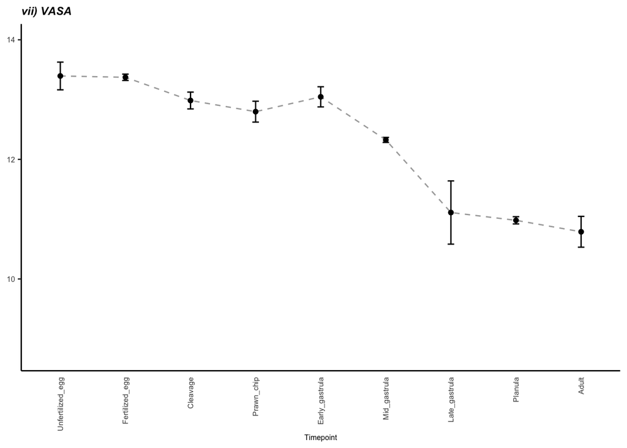

```r
Mcap.VASA <- VASA.counts %>% subset(gene_id%in%top_VASA) %>%
  ggplot(aes(x=time_point, y=mean, group=gene_id)) +
  geom_errorbar(aes(ymin=mean-sd, ymax=mean+sd), width=.1) +
  geom_line(lty="dashed", color = "darkgrey") +
  geom_point(aes(), size = 1.5) +
  xlab("Timepoint") +
  ylab(expression(paste("Mean expression (vst-transformed counts)"))) +
  theme_bw() + #Set the background color
  ylim(8.728599, 14) +
  theme(axis.line = element_line(color = 'black'), #Set the axes color
        panel.border = element_blank(), #Set the border
        panel.grid.major = element_blank(), #Set the major gridlines
        panel.grid.minor = element_blank(), #Set the minor gridlines
        plot.background=element_blank(),  #Set the plot background
        axis.title.x=element_text(size = 6), #set x-axis title size
        axis.text.x=element_text(angle = 90, vjust = 0.5, hjust=1, size = 6), #set x-axis label size
        axis.text.y=element_text(size = 6), #set x-axis label size
        axis.title.y=element_blank(), #set x-axis label size
        axis.ticks.x=element_blank(), #No x-label ticks
        legend.text=element_text(size = 6), #Legend text size
        legend.title=element_text(size = 6), #Legend title size
        legend.position = c(0.75, 0.9)) +
  #guides(shape=guide_legend(ncol=2)) +
  ggtitle("vii) VASA") +
  #facet_grid(rows=vars(gene_id), scales="free_y") +
  theme(strip.text.y = element_text(size = 5)) +
  theme(plot.title = element_text(face = 'bold.italic',
                                  size = 9,
                                  hjust = 0)) #+
  #annotate("text", x = 3.25, y = 14, label = "chromatin accessibility", size = 2.5)
Mcap.VASA
```

Compile plots into single figure and save

```r
library(patchwork)
```

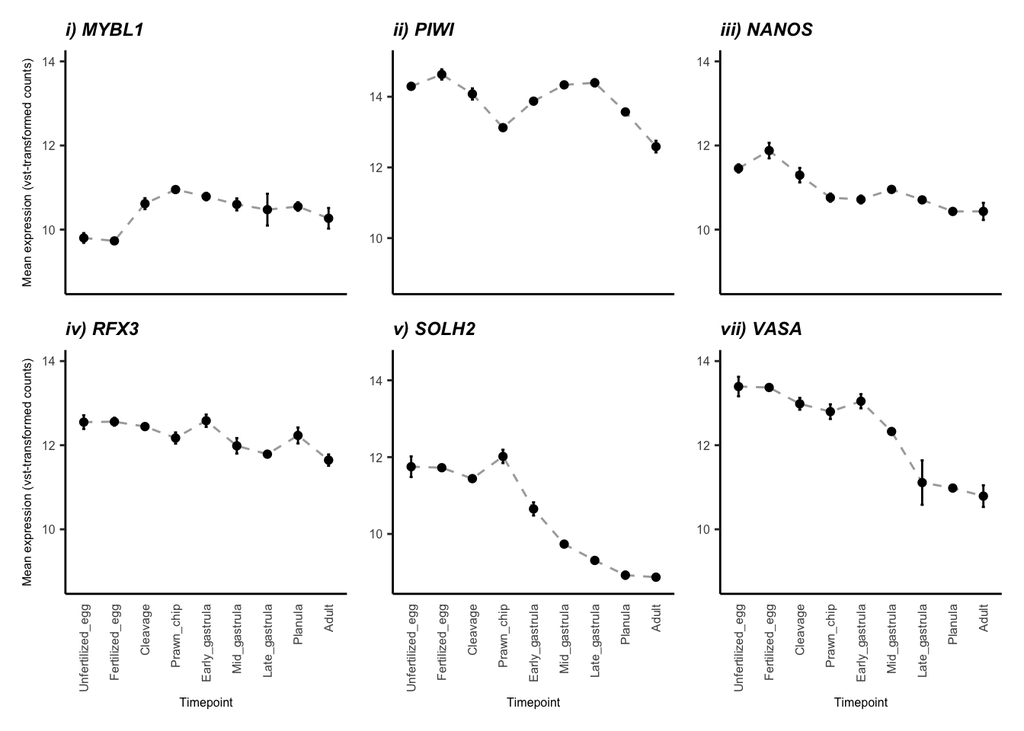

```r
Fig.7 <- (Mcap.MYBL1 + Mcap.PIWI + Mcap.NANOS) / (Mcap.RFX3 + Mcap.SOLH2 + Mcap.VASA)
Fig.7
```

```r
ggsave("2b-Epi-MZT-Enzyme-Expression/Output/Mcap-Stem-Expression.png", Fig.7, width=7, height=5)
```

# Run differential expression analysis to see if any biomarkers are differentially expressed

Run differential expression test using a Wald model.

```r
DEG_dev <- DESeq(gdds_dev) #run differential expression test by group using the Wald model
```

Make a list of biomarkers to look for:

```r
stem.markers <- c(top_MYBL1, top_NANOS, top_RFX3, top_SOLH2, top_VASA, top_PIWI)
```

Look for differential expression of biomarkers

```r
DESeq.results.fe_vs_ue <-  results(DEG_dev, name="time_point_Fertilized_egg_vs_Unfertilized_egg")
DESeq.results.fe_vs_ue <- as.data.frame(DESeq.results.fe_vs_ue)
DESeq.results.fe_vs_ue$contrast <- c("Fertilized_egg_vs_Unfertilized_egg")
DESeq.results.fe_vs_ue$gene_id <-  rownames(DESeq.results.fe_vs_ue)
fe_vs_ue.DEGs <- filter(DESeq.results.fe_vs_ue, padj<0.05)
nrow(fe_vs_ue.DEGs) #N DEGs
```

```
## [1] 2151
```

```r
stem.DEGs.fe_vs_ue <- filter(DESeq.results.fe_vs_ue, gene_id%in%stem.markers, padj<0.05)

DESeq.results.clvg_vs_fe <-  results(DEG_dev, contrast= c("time_point","Cleavage","Fertilized_egg"))
DESeq.results.clvg_vs_fe <- as.data.frame(DESeq.results.clvg_vs_fe)
DESeq.results.clvg_vs_fe$contrast <- c("Cleavage_vs_Fertilized_egg")
DESeq.results.clvg_vs_fe$gene_id <-  rownames(DESeq.results.clvg_vs_fe)
clvg_vs_fe.DEGs <- filter(DESeq.results.clvg_vs_fe, padj<0.05)
nrow(clvg_vs_fe.DEGs) #N DEGs
```

```
## [1] 9326
```

```r
stem.DEGs.clvg_vs_fe <- filter(DESeq.results.clvg_vs_fe, gene_id%in%stem.markers, padj<0.05)

DESeq.results.pc_vs_clvg <-  results(DEG_dev, contrast= c("time_point","Prawn_chip","Cleavage"))
DESeq.results.pc_vs_clvg <- as.data.frame(DESeq.results.pc_vs_clvg)
DESeq.results.pc_vs_clvg$contrast <- c("Prawn_chip_vs_Cleavage")
DESeq.results.pc_vs_clvg$gene_id <-  rownames(DESeq.results.pc_vs_clvg)
pc_vs_clvg.DEGs <- filter(DESeq.results.pc_vs_clvg, padj<0.05)
nrow(pc_vs_clvg.DEGs) #N DEGs
```

```
## [1] 8409
```

```r
stem.DEGs.pc_vs_clvg <- filter(DESeq.results.pc_vs_clvg, gene_id%in%stem.markers, padj<0.05)

DESeq.results.eg_vs_pc <-  results(DEG_dev, contrast= c("time_point", "Early_gastrula","Prawn_chip"))
DESeq.results.eg_vs_pc <- as.data.frame(DESeq.results.eg_vs_pc)
DESeq.results.eg_vs_pc$contrast <- c("Early_gastrula_vs_Prawn_chip")
DESeq.results.eg_vs_pc$gene_id <-  rownames(DESeq.results.eg_vs_pc)
eg_vs_pc.DEGs <- filter(DESeq.results.eg_vs_pc, padj<0.05)
nrow(eg_vs_pc.DEGs) #N DEGs
```

```
## [1] 9488
```

```r
stem.DEGs.eg_vs_pc <- filter(DESeq.results.eg_vs_pc, gene_id%in%stem.markers, padj<0.05)

DESeq.results.mg_vs_eg <-  results(DEG_dev, contrast= c("time_point", "Mid_gastrula", "Early_gastrula"))
DESeq.results.mg_vs_eg <- as.data.frame(DESeq.results.mg_vs_eg)
DESeq.results.mg_vs_eg$contrast <- c("Mid_gastrula_vs_Early_gastrula")
DESeq.results.mg_vs_eg$gene_id <-  rownames(DESeq.results.mg_vs_eg)
mg_vs_eg.DEGs <- filter(DESeq.results.mg_vs_eg, padj<0.05)
nrow(mg_vs_eg.DEGs) #N DEGs
```

```
## [1] 7136
```

```r
stem.DEGs.mg_vs_eg <- filter(DESeq.results.mg_vs_eg, gene_id%in%stem.markers, padj<0.05)

DESeq.results.lg_vs_mg <-  results(DEG_dev, contrast= c("time_point","Late_gastrula","Mid_gastrula"))
DESeq.results.lg_vs_mg <- as.data.frame(DESeq.results.lg_vs_mg)
DESeq.results.lg_vs_mg$contrast <- c("Late_gastrula_vs_Mid_gastrula")
DESeq.results.lg_vs_mg$gene_id <-  rownames(DESeq.results.lg_vs_mg)
lg_vs_mg.DEGs <- filter(DESeq.results.lg_vs_mg, padj<0.05)
nrow(lg_vs_mg.DEGs) #N DEGs
```

```
## [1] 4336
```

```r
stem.DEGs.lg_vs_mg <- filter(DESeq.results.lg_vs_mg, gene_id%in%stem.markers, padj<0.05)

DESeq.results.pln_vs_lg <-  results(DEG_dev, contrast= c("time_point", "Planula", "Late_gastrula"))
DESeq.results.pln_vs_lg <- as.data.frame(DESeq.results.pln_vs_lg)
DESeq.results.pln_vs_lg$contrast <- c("Planula_vs_Late_gastrula")
DESeq.results.pln_vs_lg$gene_id <-  rownames(DESeq.results.pln_vs_lg)
pln_vs_lg.DEGs <- filter(DESeq.results.pln_vs_lg, padj<0.05)
nrow(pln_vs_lg.DEGs) #N DEGs
```

```
## [1] 4347
```

```r
stem.DEGs.pln_vs_lg <- filter(DESeq.results.pln_vs_lg, gene_id%in%stem.markers, padj<0.05)

DESeq.results.adult_vs_pln <-  results(DEG_dev, contrast= c("time_point", "Adult","Planula"))
DESeq.results.adult_vs_pln <- as.data.frame(DESeq.results.adult_vs_pln)
DESeq.results.adult_vs_pln$contrast <- c("Adult_vs_Planula")
DESeq.results.adult_vs_pln$gene_id <-  rownames(DESeq.results.adult_vs_pln)
adult_vs_pln.DEGs <- filter(DESeq.results.adult_vs_pln, padj<0.05)
nrow(adult_vs_pln.DEGs) #N DEGs
```

```
## [1] 6899
```

```r
stem.DEGs.adult_vs_pln <- filter(DESeq.results.adult_vs_pln, gene_id%in%stem.markers, padj<0.05)
```

Bind results. Add enzyme names for biomarker files.

```r
stem_DEGs <- bind_rows(stem.DEGs.fe_vs_ue, stem.DEGs.clvg_vs_fe, stem.DEGs.pc_vs_clvg, stem.DEGs.eg_vs_pc, stem.DEGs.mg_vs_eg, stem.DEGs.lg_vs_mg, stem.DEGs.pln_vs_lg, stem.DEGs.adult_vs_pln)
stem_DEGs <- merge(stem_DEGs, hits[,c(1,2)], by="gene_id")
stem_DEGs
```

```
##               gene_id   baseMean log2FoldChange     lfcSE       stat
## 1  adi2mcaRNA36621_R2  5426.9536     -1.5454637 0.3016509  -5.123352
## 2  adi2mcaRNA36621_R2  5426.9536     -0.8388708 0.2748299  -3.052327
## 3              g41670  1305.8533     -2.2419322 0.2741099  -8.178953
## 4              g41670  1305.8533     -2.0099241 0.2351836  -8.546192
## 5              g41670  1305.8533      0.7740322 0.2339330   3.308778
## 6              g41670  1305.8533     -1.9908269 0.3244508  -6.135989
## 7              g41670  1305.8533     -3.4639722 1.3055773  -2.653211
## 8              g41670  1305.8533     -4.4084873 0.5899268  -7.472939
## 9              g45492  4048.4544      0.4913391 0.1472436   3.336912
## 10             g45492  4048.4544     -0.7528529 0.1478741  -5.091175
## 11             g45492  4048.4544      0.5706696 0.1649501   3.459651
## 12             g45492  4048.4544     -0.7208714 0.1651456  -4.365067
## 13             g47070   668.6756      2.1867959 0.3374639   6.480088
## 14             g56764  1241.0542     -0.7960077 0.2071867  -3.841983
```

[output cut: 31 more lines]

```r
length(levels(factor(stem_DEGs$Enzyme_Name)))
```

```
## [1] 6
```

```r
levels(factor(stem_DEGs$Enzyme_Name))
```

```
## [1] "MYBL1" "NANOS" "PIWI"  "RFX3"  "SOLH2" "VASA"
```

```r
#save
write_csv(stem_DEGs, file = "2b-Epi-MZT-Enzyme-Expression/Output/stem_biomarker_DEGs.csv")
```